# Practical: conditioning and partial ordination

Physalia workshop on GLLVMs

Bert van der Veen

# Background

In this practical we explore how to take information *out* of an ordination, using conditioning to remove variation due to nuisance factors, and combining conditioning with constrained ordination to perform partial ordination.

Key concepts from the lecture:

- **Conditioning**: placing effects outside the ordination (in `formula` or `row.eff`) removes their contribution from the latent variables
- **Partial ordination**: combining conditioning (effects outside) with constrained ordination (effects inside via `lv.formula`)
- **Variance partitioning** (`VP()`): quantifying the contribution of each model component
- **Nested designs**: `lvCor` places the ordination at a higher grouping level; `row.eff` accommodates plot-level variation

We use the wadden sea macrozoobenthos data, which has a nested structure (transects within islands) and environmental covariates.

```r
library(gllvm)
TMB::openmp(parallel::detectCores()-1, autopar = TRUE, DLL = "gllvm")
```

```
## gllvm
##    11
## attr(,"autopar")
## [1] TRUE
```

```r
Y <- read.csv("../../data/waddenY2.csv")[, -c(1:2)]
Y <- Y[, colSums(ifelse(Y == 0, 0, 1)) > 2]
X <- read.csv("../../data/waddenX.csv")
X <- X[, !apply(X, 2, anyNA)]
X[, unlist(lapply(X, is.numeric))] <- scale(X[, unlist(lapply(X, is.numeric))])
```

# Part I: Unconstrained ordination and conditioning

Start with an unconstrained ordination: no covariates, no conditioning.

```r
model1 <- gllvm(Y, num.lv = 2, family = "tweedie", Power = NULL,
                disp.formula = rep(1, ncol(Y)), n.init = 3)
```

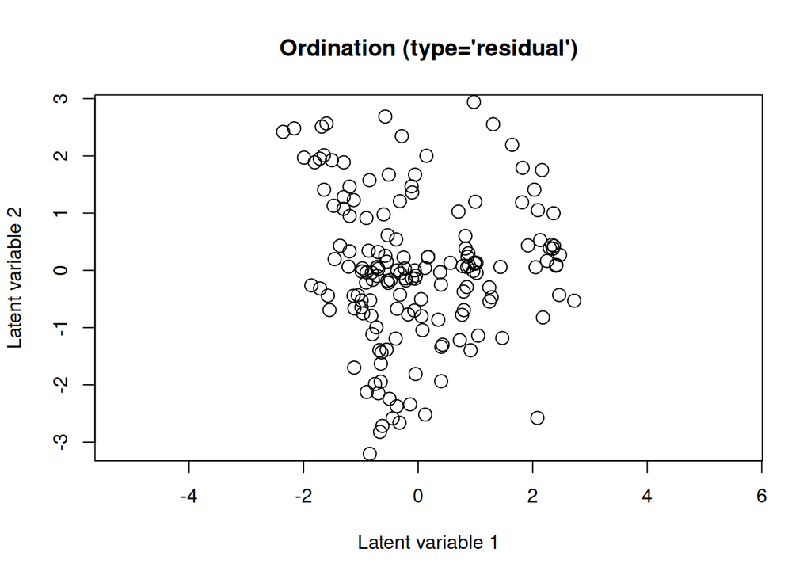

```r
gllvm::ordiplot(model1, symbols = TRUE, s.cex = 1.5)
```

Now condition on island (a nuisance factor) using `row.eff`:

```r
model2 <- gllvm(Y, num.lv = 2, family = "tweedie", Power = NULL,
                disp.formula = rep(1, ncol(Y)),
                row.eff = ~(1|island), studyDesign = X, n.init = 3)
```

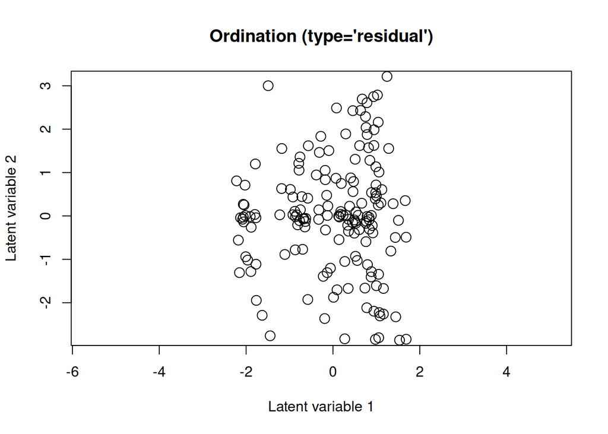

```r
gllvm::ordiplot(model2, symbols = TRUE, s.cex = 1.5)
```

Compare the two ordinations using a Procrustes rotation:

```r
vegan::procrustes(getLV(model1), getLV(model2), symmetric = TRUE)
```

```
##
## Call:
## vegan::procrustes(X = getLV(model1), Y = getLV(model2), symmetric = TRUE)
##
## Procrustes sum of squares:
## 0.01064
```

## Tasks I

1. Fit both models and compare the ordinations visually. Does conditioning on island change the pattern?
2. Use `vegan::procrustes` to quantify how similar the ordinations are.
3. Try conditioning on `transect` instead of `island`. Does the ordination change further?
4. What does conditioning on a nuisance factor do to the interpretation of the ordination axes?

# Part II: Constrained and partial ordination

Now combine conditioning with constrained ordination. We condition on island (remove its effect) while constraining the ordination with environmental variables.

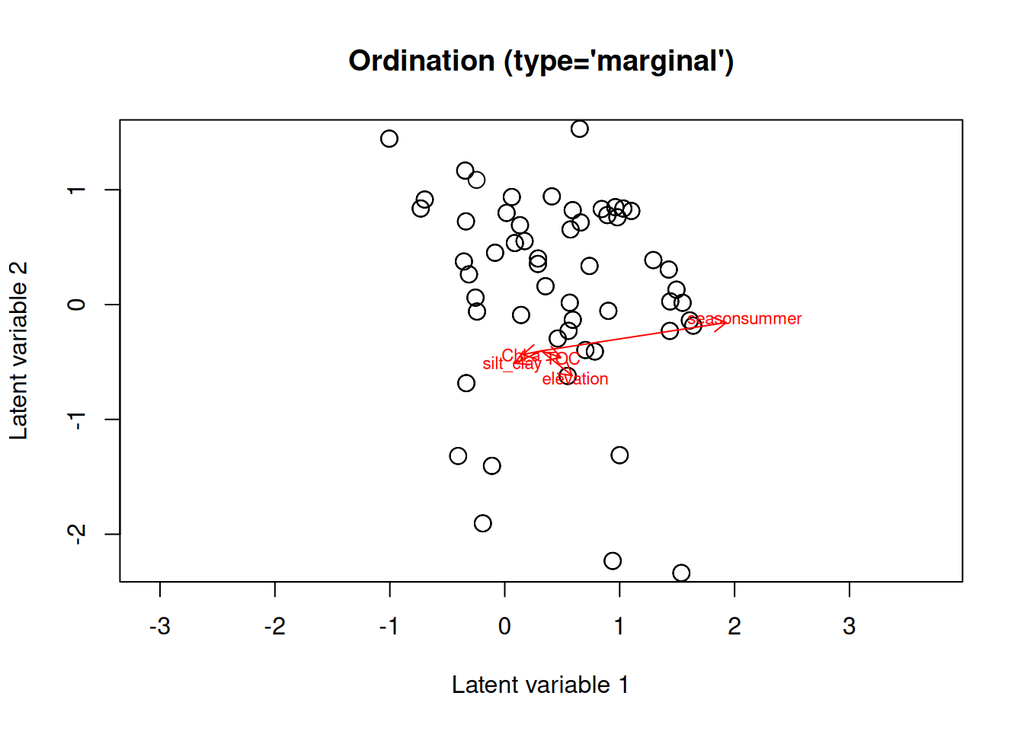

```r
model3 <- gllvm(Y, X = X,
                lv.formula = ~season + TOC + elevation + silt_clay + Chl.a,
                num.RR = 2, randomB = "LV",
                family = "tweedie", Power = NULL,
                disp.formula = rep(1, ncol(Y)),
                row.eff = ~(1|island), studyDesign = X,
                n.init = 3)
gllvm::ordiplot(model3, symbols = TRUE, s.cex = 1.5, arrow.ci = FALSE)
```

This is a **partial constrained ordination**: we show the community variation explained by the environment, after removing the island effect.

## Tasks II

1. Fit the partial constrained ordination and interpret the ordination plot. Which environmental variables drive the main axes?
2. Try removing the conditioning (`row.eff`): how does the constrained ordination change?
3. Switch from `num.RR` to `num.lv.c` (concurrent ordination). What is the difference in interpretation?
4. Use `coefplot(model3, which.Xcoef = "TOC")` to examine species-specific TOC effects.

# Part III: Variance partitioning

Variance partitioning (`VP()`) shows the relative contribution of each model component.

```r
VP(model3)
```

[output not shown]

## Tasks III

1. Run `VP()` on model3. Which component explains the most variation?
2. Fit a model with more environmental variables and compare the VP output. Does adding more covariates increase the explained variation?
3. Try fitting a model with both `formula` (species-specific fixed effects) and `lv.formula` (constrained ordination). Use `VP()` to partition variance between these components.
4. Which grouping would you use in `VP()` to contrast “environment” vs “residual”?
5. Compare the `getResidualCov(model1)$trace` and `getResidualCov(model2)$trace`. Does conditioning reduce unexplained variation?